# Downstream analyses (all)

### Features in cic_clinical_data_v2.xlsx (summary sheet):

```r
colnames(sheet_1)
```

```
 [1] "database.code"
 [2] "Study.ID"
 [3] "Centre"
 [4] "Study"
 [5] "RNA.extraction"
 [6] "Library.Prep"
 [7] "Myriad"
 [8] "Batch..Ian."
 [9] "visual.loss.at.BL..0.no..1.yes."
[10] "visual.loss.ever...0.no..1.yes."
[11] "AION.or.PION.BL...0.no..1.yes..99.not.assessed."
[12] "AION.or.PION.ever...0.no..1.yes..99.not.assessed."
[13] "jaw.claudication.at.BL...0.no..1.yes."
[14] "ischaemic.features.at.BL...0.no..1.yes."
[15] "tongue.claudication..0.no..1.yes..2.unk."
[16] "gender..1.male..2.female."
[17] "year.TAB.sample.was.collected"
[18] "number.of.days.on.steroids.at.TAB"
[19] "number.of.days.between.TAB.and.BL.blood.sample"
```

Total number of cases: 41 for each feature (some might contain missing data)

How many class (levels) for each feature?

```
 [1] 41 41 10  3  1  1  2  2  2  2  3  3  2  2  3  2  6 12 14
```

NOTE: 1st and 2nd columns (database.code & Study.ID) can be ignored as they have 41 levels, as well as, 5th and 6th (RNA.extraction & Library.Prep) as they have 1 level only.

How many cases in each class?

OUTPUT EXAMPLE

```
### Feature: [name_of_clinical_feature] ###
 Class: [X] => count: [Y]
```

```
### Myriad ###
2 =>  26
1 =>  15

### Batch..Ian. ###
1 =>  26
2 =>  15

### visual.loss.at.BL..0.no..1.yes. ###
0 =>  24
1 =>  17

### visual.loss.ever...0.no..1.yes. ###
0 =>  24
1 =>  17

### AION.or.PION.BL...0.no..1.yes..99.not.assessed. ###
99 =>  26
0 =>  10
1 =>  5

### AION.or.PION.ever...0.no..1.yes..99.not.assessed. ###
99 =>  25
0 =>  10
1 =>  6

### jaw.claudication.at.BL...0.no..1.yes. ###
1 =>  24
0 =>  17

### ischaemic.features.at.BL...0.no..1.yes. ###
1 =>  31
0 =>  10

### tongue.claudication..0.no..1.yes..2.unk. ###
0 =>  35
1 =>  5
2 =>  1

### gender..1.male..2.female. ###
```

[output cut: 25 more lines]

```
### number.of.days.between.TAB.and.BL.blood.sample ###
4 =>  1
12 =>  2
3 =>  7
7 =>  5
5 =>  1
6 =>  1
11 =>  6
8 =>  2
2 =>  5
14 =>  1
9 =>  4
10 =>  4
13 =>  1
1 =>  1
```

Features to be taken into account in the analysis of clinical summary:

- **Myriad** (15 – 26) => ???
- **Batch** (26 – 15) => same as **gender**, except for 16649
- **visual.loss.at.BL** (24 – 17) => same as **visual.loss.ever** => OK
- **AION.or.PION.BL** (10 – 5 | 26 not assessed) => almost the same as **AION.or.PION.ever**; uninformative
- **jaw.claudication.at.BL** (17 – 24) => OK
- **ischaemic.features.at.BL** (10 – 31) => OK
- **tongue.claudication** (35 – 5 | 1 unknown) => probably uninformative
- **year.TAB.sample.was.collected** (2006:1 – 2010:2 – 2011:7 – 2012:18 – 2013:12 – 2015:1) => not sure
- **number.of.days.on.steroids.at.TAB** (1:2 – 2:1 – 3:2 – 4:1 – 5:8 – 6:5 – 7:3 – 8:6 – 9:9 – 10:2 – 11:1 – 12:1)
- **number.of.days.between.TAB.and.BL.blood.sample** (1:1 – 2:5 – 3:7 – 4:1 – 5:1 – 6:1 – 7:5 – 8:2 – 9:4 – 10:4 – 11:6 – 12:2 – 13:1 – 14:1)

### Features in slide_scores_v6.csv:

```r
colnames(slide_sc) # dim = 40 25; one sample is missing
```

```
 [1] "Database.number"
 [2] "Section.number"
 [3] "GCA.present."
 [4] "Any.granulomatous.infiltrate."
 [5] "Granulomatous.infiltrate.in.adventitia."
 [6] "Granulomatous.infiltrate.in.media."
 [7] "Granulomatous.infiltrate.in.intima."
 [8] "Any.lymphocytic.infiltrate."
 [9] "X"
[10] "Lymphocytic.infiltrate.in.media."
[11] "Lymphocytic.infiltrate.in.intima."
[12] "Barcelona.score."
[13] "Adventitia.pattern."
[14] "Media.pattern."
[15] "Intima.pattern."
[16] "Giant.cells."
[17] "Aggregates."
[18] "Infiltrate.around.vasa.vasorum."
[19] "PALI."
[20] "Media.destruction."
[21] "Neoangiogenesis."
[22] "Hyperplasia."
[23] "Fibrosis."
[24] "Oedema."
[25] "Occlusion.grade."
```

Total number of cases: 40 for each feature (some might contain missing data)

How many class (levels) for each feature?

```
 [1] 40  1  2  2  2  1  2  2  2  2  2  4  3  4  4  2  2  2  2  2  2  2  2  2  5
```

NOTE: 1st column (Database.number) can be ignored as it has 40 levels, as well as, 2nd and 6th (Section.number & Granulomatous.infiltrate.in.media.) as they have 1 level only.

How many cases in each class?

```
### Granulomatous.infiltrate.in.adventitia. ###
0 =>  38
1 =>  2

### Granulomatous.infiltrate.in.intima. ###
0 =>  39
1 =>  1

### Any.lymphocytic.infiltrate. ###
1 =>  32
0 =>  8

### X ###
1 =>  32
0 =>  8

### Lymphocytic.infiltrate.in.media. ###
0 =>  12
1 =>  28

### Lymphocytic.infiltrate.in.intima. ###
1 =>  31
0 =>  9

### Barcelona.score. ###
3 =>  6
4 =>  25
0 =>  8
2 =>  1

### Adventitia.pattern. ###
2 =>  8
3 =>  24
0 =>  8

### Media.pattern. ###
0 =>  14
2 =>  13
1 =>  7
3 =>  6
```

[output cut: 34 more lines]

```

### Fibrosis. ###
1 =>  31
0 =>  9

### Oedema. ###
0 =>  35
1 =>  5

### Occlusion.grade. ###
1 =>  3
3 =>  21
4 =>  1
0 =>  9
2 =>  6
```

### Batch effects

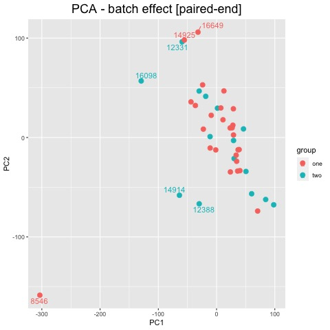

Principal Components Analysis

### Comparison between gender

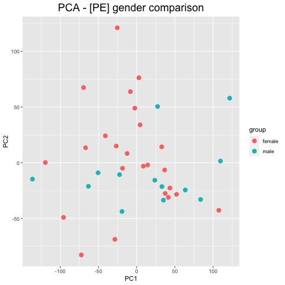

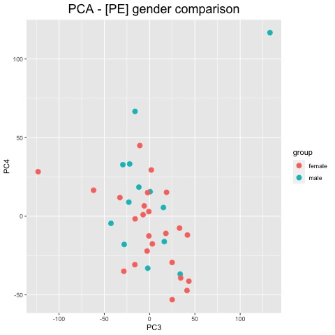

Comparison between gender - PCA

Variance explained:  
**PC1: 20.7%** | **PC2: 10.2%** | **PC3: 8.7%** | **PC4: 6.5%**

### clincial features:

#### visual.loss.at.BL

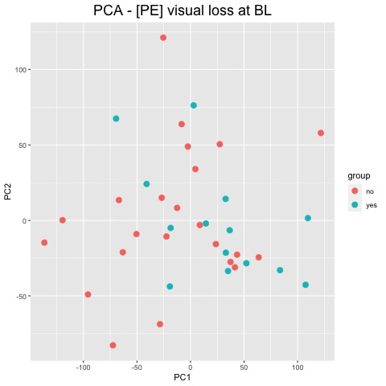

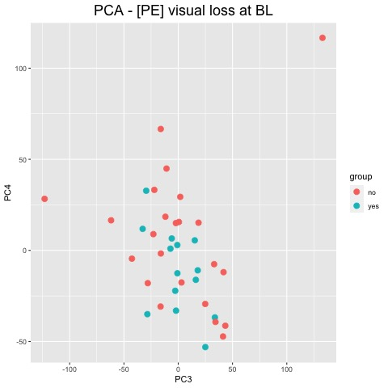

Visual loss at BL - PCA

#### jaw.claudication.at.BL

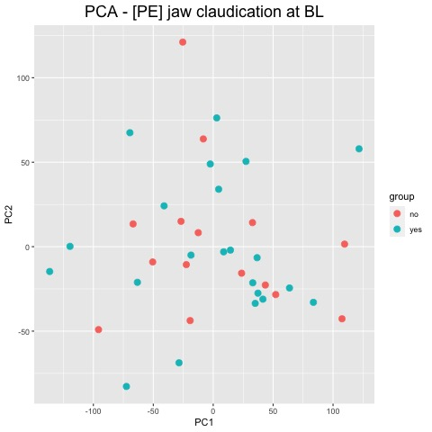

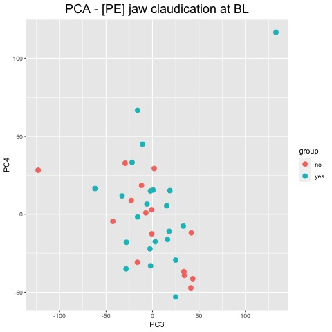

Jaw claudication at BL - PCA

#### ischaemic.features.at.BL

[figure not shown]

[figure not shown]

Ischaemic features at BL - PCA